# Homework #4

Beatriz Wahle

2024-11-08

Loading alll the libraries at the beginning;.

```r
library(C50)
library(caret)
library(neuralnet)
library(class)
library(kernlab)
library(smotefamily)
```

### 1. Import and clean the data

Get the data:

```r
tele_data <- read.csv("tele.csv")
```

Removing unnecessary columns:

```r
tele_data$X <- NULL
tele_data$duration <- NULL
```

Handling the Pdays column:

```r
table(tele_data$pdays)
```

```
##
##     0     1     2     3     4     5     6     7     8     9    10    11    12
##    15    26    61   439   118    46   412    60    18    64    52    28    58
##    13    14    15    16    17    18    19    20    21    22    25    26    27
##    36    20    24    11     8     7     3     1     2     3     1     1     1
##   999
## 39673
```

```r
called <- sum(ifelse(tele_data$pdays < 999, 1,0))
never_called <- sum(length(tele_data$pdays))
called_ratio <- (called / (called + never_called))*100
print(paste('The percentage of clients called in this variable is ', round(called_ratio,2),'% of the total database'))
```

```
## [1] "The percentage of clients called in this variable is  3.55 % of the total database"
```

```r
tele_data$pdays <- ifelse(tele_data$pdays == 999, 0, 1)
```

### 2. Convert factors into dummy variables using model.matrix command + some additional preprocessing

```r
#ENCODING
encoded_data <- as.data.frame(model.matrix(~ . -1, tele_data))
encoded_data$jobunknown <- NULL
encoded_data$y <- encoded_data$yyes
encoded_data$yyes <- NULL
row.names(encoded_data) <- NULL

#SCALING
minmax <- function(x) {
  (x - min(x)) / (max(x)-min(x))
}
scaled_data <- as.data.frame(lapply(encoded_data, minmax))
```

### 3. Separate into train and test dataset using a 50:50 split.

```r
test_rate <- 0.5
set.seed(666)

# Decision Tree, SVM and Logistic Regression Split - Encoded
test_encoded_rows <- sample(1:nrow(encoded_data), test_rate*nrow(encoded_data))
train_encoded <- encoded_data[test_encoded_rows, ]
test_encoded <- encoded_data[-test_encoded_rows, ]

# KNN, ANN Split - Encoded and Scaled
train_scaled <- scaled_data[test_encoded_rows, ]
test_scaled <- scaled_data[-test_encoded_rows, ]
```

### 4. Build the models:

**Logistic Regression** Built a simple logistic regression and rather than pursuing a computationally-intensive process of building a giant model, use a step one that simplifies it, this approach builds a simple model and then it performs a stepwise selection on the simple model.

```r
lr <- glm(y ~ ., data = train_encoded, family = binomial)
stepwise_lr <- step(lr, direction = "both", trace = 0)

prediction_lr <- predict(stepwise_lr, test_encoded, type = "response")
binary_prediction_lr <- ifelse(prediction_lr < .25, 0, 1)

confusionMatrix(as.factor(binary_prediction_lr),
                as.factor(test_encoded$y),
                positive = "1")
```

```
## Confusion Matrix and Statistics
##
##           Reference
## Prediction     0     1
##          0 17024  1166
##          1  1280  1124
##
##                Accuracy : 0.8812
##                  95% CI : (0.8767, 0.8856)
##     No Information Rate : 0.8888
##     P-Value [Acc > NIR] : 0.99971
##
##                   Kappa : 0.4119
##
##  Mcnemar's Test P-Value : 0.02232
##
##             Sensitivity : 0.49083
##             Specificity : 0.93007
##          Pos Pred Value : 0.46755
##          Neg Pred Value : 0.93590
##              Prevalence : 0.11120
##          Detection Rate : 0.05458
##    Detection Prevalence : 0.11673
##       Balanced Accuracy : 0.71045
##
##        'Positive' Class : 1
##
```

The logistic regression model achieved an accuracy of 88.12%, indicating good overall performance; however, this is heavily influenced by the class imbalance, where the majority class dominates. I did not use a balancing technique because I do not want to balance the dataset for some of the other models, and when combine the five, I need the same number of rows to build the final data frame. The Kappa statistic of 0.4119 suggests moderate agreement between the predicted and true labels, but there’s room for improvement in distinguishing the classes. Sensitivity is low at 49.08%, meaning the model identifies fewer than half of the positive cases, while specificity is strong at 93.01%, showing excellent performance in identifying negatives. Improving sensitivity is crucial, especially in scenarios where correctly identifying the minority class is important.

**KNN**

```r
y_col <- which(colnames(train_scaled) == "y")
prediction_knn <- knn(train = train_scaled[,-y_col],
                      test = test_scaled[,-y_col],
                      cl = train_scaled[,y_col],
                      k = 1)
summary(prediction_knn)
```

```
##     0     1
## 18344  2250
```

```r
confusionMatrix(as.factor(prediction_knn), as.factor(test_scaled$y), positive = "1")
```

```
## Confusion Matrix and Statistics
##
##           Reference
## Prediction     0     1
##          0 16738  1606
##          1  1566   684
##
##                Accuracy : 0.846
##                  95% CI : (0.841, 0.8509)
##     No Information Rate : 0.8888
##     P-Value [Acc > NIR] : 1.0000
##
##                   Kappa : 0.2148
##
##  Mcnemar's Test P-Value : 0.4886
##
##             Sensitivity : 0.29869
##             Specificity : 0.91444
##          Pos Pred Value : 0.30400
##          Neg Pred Value : 0.91245
##              Prevalence : 0.11120
##          Detection Rate : 0.03321
##    Detection Prevalence : 0.10926
##       Balanced Accuracy : 0.60657
##
##        'Positive' Class : 1
##
```

**ANN**

```r
ann <- neuralnet(y ~ ., data = data.frame(train_scaled), hidden = 1, stepmax = 1e6, lifesign = "none", learningrate = 0.1)
plot(ann)

prediction_ann <- predict(ann, newdata = data.frame(test_scaled))
summary(prediction_ann)
```

[output not shown]

```
##        V1
##  Min.   :0.02044
##  1st Qu.:0.03959
##  Median :0.05493
##  Mean   :0.11308
##  3rd Qu.:0.09440
##  Max.   :0.87510
```

```r
binary_prediction_ann <- ifelse(prediction_ann > 0.25, 1, 0)
confusionMatrix(as.factor(binary_prediction_ann),
                as.factor(test_scaled$y),
                positive = "1")
```

```
## Confusion Matrix and Statistics
##
##           Reference
## Prediction     0     1
##          0 16977  1146
##          1  1327  1144
##
##                Accuracy : 0.8799
##                  95% CI : (0.8754, 0.8843)
##     No Information Rate : 0.8888
##     P-Value [Acc > NIR] : 0.9999714
##
##                   Kappa : 0.4128
##
##  Mcnemar's Test P-Value : 0.0002951
##
##             Sensitivity : 0.49956
##             Specificity : 0.92750
##          Pos Pred Value : 0.46297
##          Neg Pred Value : 0.93677
##              Prevalence : 0.11120
##          Detection Rate : 0.05555
##    Detection Prevalence : 0.11999
##       Balanced Accuracy : 0.71353
##
##        'Positive' Class : 1
##
```

**SVM** In order to have the best SVM model possible, I did a function that runs the support vector machine with all the kernels and the outputs are the accuracy, kappa, and senstivity of each. That makes it easir to choose which kernel to use for the final model.

```r
try_kernels <- function(kernel_name) {
  model <- ksvm(as.factor(y) ~ ., data = train_scaled, kernel = kernel_name)
  predictions <- predict(model, test_scaled)
  cm <- confusionMatrix(as.factor(predictions), as.factor(test_scaled$y), positive = "1")

  accuracy <- cm$overall["Accuracy"]
  kappa <- cm$overall["Kappa"]
  sensitivity <- cm$byClass["Sensitivity"]

  # Return all metrics
  return(c(accuracy = accuracy, kappa = kappa, sensitivity = sensitivity))
}


kernels <- c("vanilladot", "polydot", "rbfdot", "tanhdot", "anovadot", "laplacedot", "besseldot")
sapply(kernels, try_kernels)
```

```
##                         vanilladot   polydot    rbfdot     tanhdot  anovadot
## accuracy.Accuracy        0.8978829 0.8978829 0.8994853  0.85957075 0.8981742
## kappa.Kappa              0.2553682 0.2553682 0.2590970 -0.03224363 0.2699551
## sensitivity.Sensitivity  0.1908297 0.1908297 0.1895197  0.01222707 0.2056769
##                         laplacedot besseldot
## accuracy.Accuracy        0.8977858 0.8996795
## kappa.Kappa              0.2595530 0.2625811
## sensitivity.Sensitivity  0.1956332 0.1925764
```

```r
svm <- ksvm(as.factor(y) ~ ., data = train_scaled,
                          kernel = "besseldot")
svm_prediction <- predict(svm, test_scaled)
confusionMatrix(as.factor(svm_prediction),
                as.factor(test_scaled$y),
                positive="1")
```

```
## Confusion Matrix and Statistics
##
##           Reference
## Prediction     0     1
##          0 18087  1849
##          1   217   441
##
##                Accuracy : 0.8997
##                  95% CI : (0.8955, 0.9038)
##     No Information Rate : 0.8888
##     P-Value [Acc > NIR] : 2.52e-07
##
##                   Kappa : 0.2626
##
##  Mcnemar's Test P-Value : < 2.2e-16
##
##             Sensitivity : 0.19258
##             Specificity : 0.98814
##          Pos Pred Value : 0.67021
##          Neg Pred Value : 0.90725
##              Prevalence : 0.11120
##          Detection Rate : 0.02141
##    Detection Prevalence : 0.03195
##       Balanced Accuracy : 0.59036
##
##        'Positive' Class : 1
##
```

The SVM model achieves an accuracy of 89.97%, indicating that most predictions align with actual values. However, the Kappa statistic of 0.2626 suggests a low agreement beyond chance, reflecting limited performance in handling class imbalance. The sensitivity (true positive rate) is only 19.26%, highlighting that the model struggles to correctly identify the positive class (1). While the specificity (true negative rate) is high at 98.81%, the imbalance between sensitivity and specificity indicates that the model is heavily biased toward the majority class, favoring predictions of 0. This suggests that the model’s performance on the minority class is inadequate and adjustments, such as class weighting or balancing, may be needed to improve sensitivity and overall balance.

**Decision Trees**

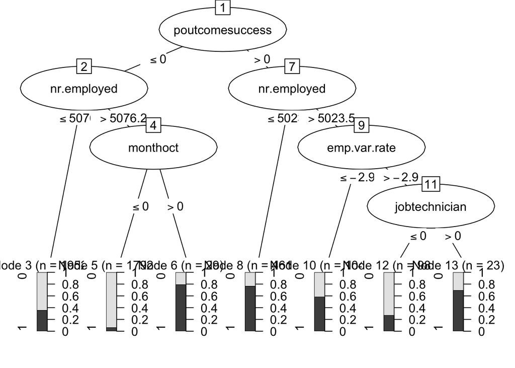

```r
library(C50)
model <- C5.0(as.factor(y) ~ ., data = train_encoded)
plot(model)
```

```r
predictions <- predict(model, newdata = test_encoded)

#confusionMatrix <- table(predictions, test_encoded$y)
confusionMatrix(as.factor(predictions),
                as.factor(test_encoded$y),
                positive="1")
```

```
## Confusion Matrix and Statistics
##
##           Reference
## Prediction     0     1
##          0 18111  1874
##          1   193   416
##
##                Accuracy : 0.8996
##                  95% CI : (0.8954, 0.9037)
##     No Information Rate : 0.8888
##     P-Value [Acc > NIR] : 2.838e-07
##
##                   Kappa : 0.2521
##
##  Mcnemar's Test P-Value : < 2.2e-16
##
##             Sensitivity : 0.18166
##             Specificity : 0.98946
##          Pos Pred Value : 0.68309
##          Neg Pred Value : 0.90623
##              Prevalence : 0.11120
##          Detection Rate : 0.02020
##    Detection Prevalence : 0.02957
##       Balanced Accuracy : 0.58556
##
##        'Positive' Class : 1
##
```

```r
cost_matrix <- matrix(c(0, 5,
                        1, 0),
                      nrow = 2,
                      byrow = TRUE)
rownames(cost_matrix) <- colnames(cost_matrix) <- c("0", "1")

model2 <- C5.0(as.factor(y) ~ ., data = train_encoded, costs = cost_matrix)

predictions2 <- predict(model2, newdata = test_encoded)

confusionMatrix(as.factor(predictions2),
                as.factor(test_encoded$y),
                positive="1")
```

```
## Confusion Matrix and Statistics
##
##           Reference
## Prediction     0     1
##          0 16443   921
##          1  1861  1369
##
##                Accuracy : 0.8649
##                  95% CI : (0.8602, 0.8696)
##     No Information Rate : 0.8888
##     P-Value [Acc > NIR] : 1
##
##                   Kappa : 0.4206
##
##  Mcnemar's Test P-Value : <2e-16
##
##             Sensitivity : 0.59782
##             Specificity : 0.89833
##          Pos Pred Value : 0.42384
##          Neg Pred Value : 0.94696
##              Prevalence : 0.11120
##          Detection Rate : 0.06648
##    Detection Prevalence : 0.15684
##       Balanced Accuracy : 0.74807
##
##        'Positive' Class : 1
##
```

**Gathering the predictions:**

```r
response <- test_encoded$y
all_predictions <- data.frame(binary_prediction_lr, prediction_knn, binary_prediction_ann, svm_prediction, predictions2, response)
str(all_predictions)
```

```
## 'data.frame':    20594 obs. of  6 variables:
##  $ binary_prediction_lr : num  0 0 0 0 0 0 0 0 0 0 ...
##  $ prediction_knn       : Factor w/ 2 levels "0","1": 1 1 1 1 1 1 1 1 1 1 ...
##  $ binary_prediction_ann: num  0 0 0 0 0 0 0 0 0 0 ...
##  $ svm_prediction       : Factor w/ 2 levels "0","1": 1 1 1 1 1 1 1 1 1 1 ...
##  $ predictions2         : Factor w/ 2 levels "0","1": 1 1 1 1 1 1 1 1 1 1 ...
##  $ response             : num  0 0 0 0 0 0 0 0 0 0 ...
```

```r
all_predictions$binary_prediction_lr <- as.factor(all_predictions$binary_prediction_lr)
all_predictions$binary_prediction_ann <- as.factor(all_predictions$binary_prediction_ann)
all_predictions$response <- as.factor(all_predictions$response)
```

```r
test_rate <- 0.3
set.seed(666)

test_prediction_rows <- sample(1:nrow(all_predictions), test_rate*nrow(all_predictions))
train_predictions <- all_predictions[test_prediction_rows, ]
test_predictions <- all_predictions[-test_prediction_rows, ]
```

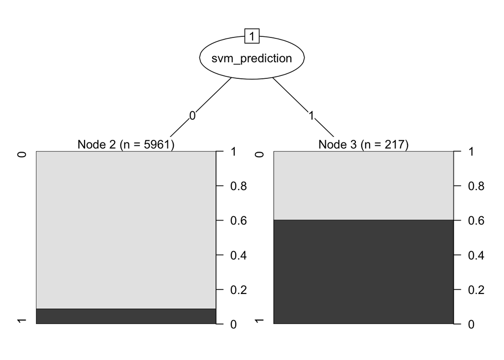

```r
model <- C5.0(as.factor(response) ~ ., data = train_predictions)
plot(model)
```

```r
predictions <- predict(model, newdata = test_predictions)

confusionMatrix <- table(predictions, test_predictions$response)
print(confusionMatrix)
```

```
##
## predictions     0     1
##           0 12655  1320
##           1   131   310
```

```r
cost_matrix_prediction <- matrix(c(0, 5,
                                  1, 0),
                                  nrow = 2,
                                  byrow = TRUE)
rownames(cost_matrix) <- colnames(cost_matrix) <- c("0", "1")

model2 <- C5.0(as.factor(response) ~ ., data = train_predictions, costs = cost_matrix_prediction)
predictions2 <- predict(model2, newdata = test_predictions)

confusionMatrix(as.factor(predictions2),
                as.factor(test_predictions$response),
                positive="1")
```

```
## Confusion Matrix and Statistics
##
##           Reference
## Prediction     0     1
##          0 11458   630
##          1  1328  1000
##
##                Accuracy : 0.8642
##                  95% CI : (0.8585, 0.8697)
##     No Information Rate : 0.8869
##     P-Value [Acc > NIR] : 1
##
##                   Kappa : 0.4294
##
##  Mcnemar's Test P-Value : <2e-16
##
##             Sensitivity : 0.61350
##             Specificity : 0.89614
##          Pos Pred Value : 0.42955
##          Neg Pred Value : 0.94788
##              Prevalence : 0.11307
##          Detection Rate : 0.06937
##    Detection Prevalence : 0.16149
##       Balanced Accuracy : 0.75482
##
##        'Positive' Class : 1
##
```

The stacked model achieves an accuracy of 86.42%, which is slightly lower than the SVM and logistic regression but comparable to the decision tree. Its Kappa (0.4294) is higher than most individual models, indicating better agreement beyond chance. Sensitivity improves significantly to 61.35%, outperforming all individual models, showing enhanced performance in identifying the positive class. Balanced accuracy (75.48%) is slightly better than the decision tree and higher than other models. Overall, the stacked model effectively improves the balance between sensitivity and specificity, making it a strong choice for handling imbalanced datasets.